# Goal 2 Univaraite: US

Jaclyn A Coate

7/21/2020

# US COVID Data

## Data Prep

```r
us <- read.csv("https://raw.githubusercontent.com/JaclynCoate/6373_Time_Series/master/TermProject/Data/USdaily.7.26.20.csv", header = T, strip.white = T)
us <- transform(us, date = as.Date(as.character(date), "%Y%m%d"))
us <- subset(us, select = -c(states, dateChecked, hospitalized, lastModified, total, posNeg, totalTestResultsIncrease, hash))
us[is.na(us)] <- 0
#Selecting only those dates with reported current hospitilizations
us <- dplyr::slice(us,1:132)
us = us[order(as.Date(us$date, format = "%Y%m%d")),]
head(us)
```

```
##           date positive negative pending hospitalizedCurrently
## 132 2020-03-17    11928    63104    1687                   325
## 131 2020-03-18    15099    84997    2526                   416
## 130 2020-03-19    19770   108407    3016                   617
## 129 2020-03-20    26025   138814    3330                  1042
## 128 2020-03-21    32910   177262    3468                  1436
## 127 2020-03-22    42169   213476    2842                  2155
##     hospitalizedCumulative inIcuCurrently inIcuCumulative
## 132                     55              0               0
## 131                     67              0               0
## 130                     85              0               0
## 129                    108              0               0
## 128                   2020              0               0
## 127                   3023              0               0
##     onVentilatorCurrently onVentilatorCumulative recovered death
```

[output cut: 20 more lines]

## Forecast Current Hospitalizations

It is difficult to assume stationarity for this data due to multiple factors. We are working under the assumption that COVID is a novel virus and cases as well as hospitalizations will eventually return to zero. This being said our current modeling techniques do things such as return to the median or mimic the previously seen trends. Also, we see a heavy wandering trend in both new cases and hospitalization would be dependent on this as well as time. We will review the data and see what, if any, non-stationary components reveal themselves and model the data accordingly.

### Original Data Realization

Traits:

- Heavy wandering behavior
- What appears to be some noise that could be pseudo-cyclic behavior hidden by the large numbers.

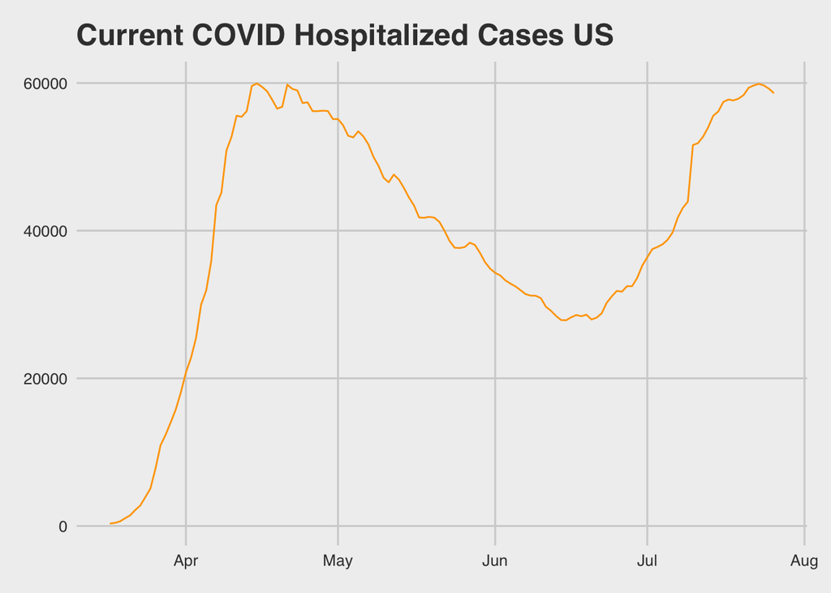

```r
ggplot(data = us, aes(x=date, y=hospitalizedCurrently))+
  geom_line(color="orange")+
  labs(title = "Current COVID Hospitalized Cases US", y = "Thousands", x = "") +
    theme_fivethirtyeight()
```

### Sample Realization, ACF, and Spectral Density

Realization:

- Heavy wandering behavior
- Possible small pseudo-cyclic behavior

ACF:

- Very slowly dampening behavior that would be consistent with a d=1 ARIMA model.

Spectral Density:

- Peak at f=0
- What appears to be a wave through the rest of the graph- this could be a hidden seasonality or another frequency peak that is hidden by the pseudo-cyclic behavior mentioned in above the realization above.

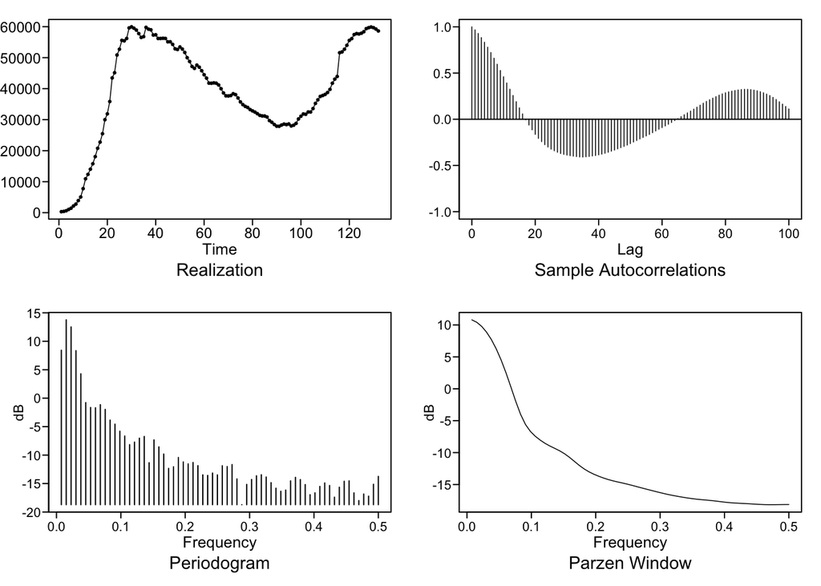

```
## $autplt
##   [1]  1.000000000  0.967247046  0.928472445  0.883791745  0.834039153
##   [6]  0.779901780  0.722099406  0.660670233  0.595507232  0.527652159
##  [11]  0.459798098  0.392707355  0.325070497  0.257394633  0.190076427
##  [16]  0.123107742  0.058045025 -0.005592108 -0.062510518 -0.114255855
##  [21] -0.163281121 -0.206979530 -0.242176807 -0.275097030 -0.300626756
##  [26] -0.323018458 -0.340862401 -0.357234304 -0.371125261 -0.380223777
##  [31] -0.387733922 -0.393904174 -0.399188337 -0.403702529 -0.407535556
##  [36] -0.409058093 -0.406032310 -0.402291057 -0.397307333 -0.392192952
##  [41] -0.385158345 -0.377444480 -0.367999137 -0.357234818 -0.345390268
##  [46] -0.333657101 -0.320405088 -0.307093151 -0.293895002 -0.279566463
##  [51] -0.263105425 -0.246363949 -0.229539058 -0.213137515 -0.196728805
##  [56] -0.180700291 -0.164151991 -0.145439160 -0.126569221 -0.107984741
##  [61] -0.090254314 -0.072242265 -0.054130291 -0.034756123 -0.014095709
##  [66]  0.007187366  0.028500485  0.048915792  0.068729196  0.088785284
```

[output cut: 55 more lines]

```r
plotts.sample.wge(us$hospitalizedCurrently, lag.max = 100)
```

### Overfit tables

Since we are seeing heavy wandering behavior we will use overfit tables to see if we can surface any (1-B) factors that have roots very near the unit circle.

- Below we are able to clearly see 1: (1-B) factor that has a root nearly on the Unit Circle.

```r
est.ar.wge(us$hospitalizedCurrently,p=6,type='burg')
```

```
##
## Coefficients of Original polynomial:
## 1.2113 0.0324 -0.0917 -0.0697 0.0013 -0.1010
##
## Factor                 Roots                Abs Recip    System Freq
## 1-1.9283B+0.9354B^2    1.0308+-0.0812i      0.9672       0.0125
## 1+0.9678B+0.3408B^2   -1.4200+-0.9583i      0.5838       0.4055
## 1-0.2507B+0.3168B^2    0.3957+-1.7322i      0.5628       0.2143
##
##
```

[output not shown]

[output cut: 29 more lines]

### Difference the data based on surfaced (1-B) Factor

Once the data has been differenced we see something that looks much closer to a stationary data set. However, we have also surfaced what appears to be a small seasonality component. We see the ACF have higher spikes surface at 7 and 14, which would lead us to believe there is a 7 day seasonal component.

```r
us.diff = artrans.wge(us$hospitalizedCurrently, phi.tr = 1, lag.max = 100)
```

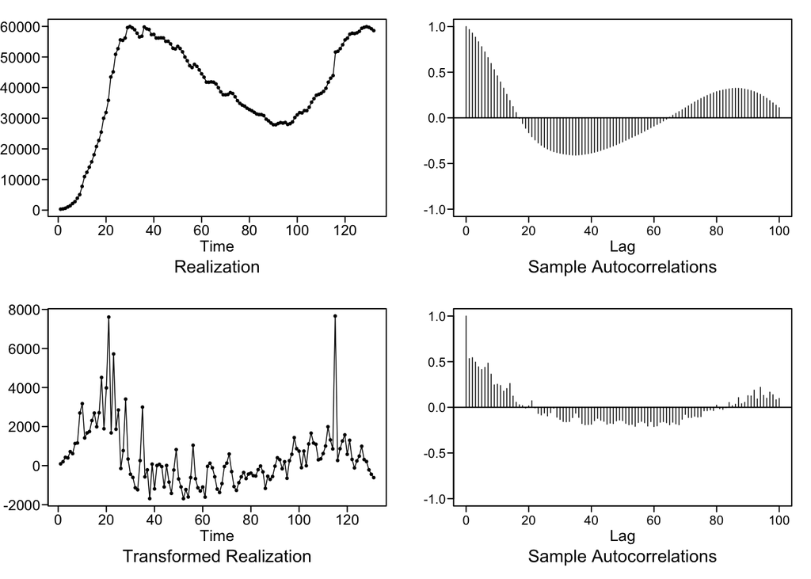

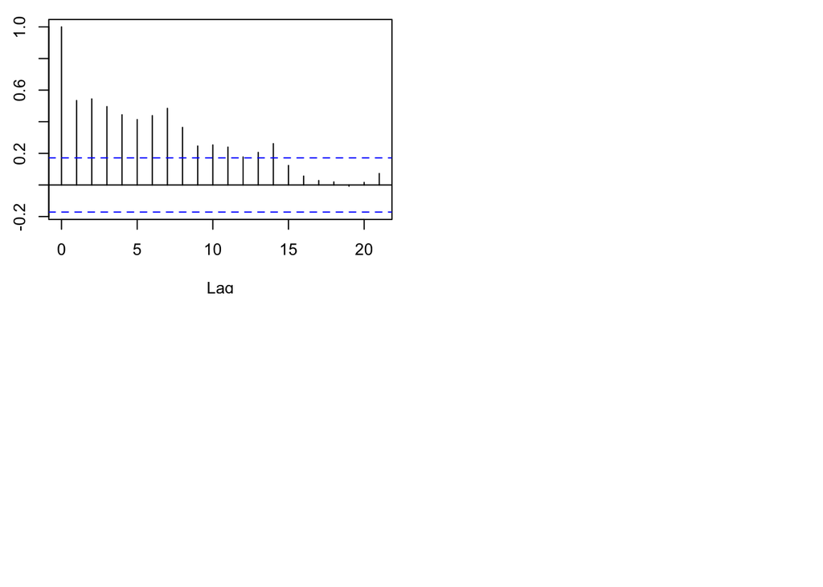

```r
acf(us.diff)
```

### Seasonailty Transformation

Above we have surfaced what appears to be a 7 day seasonality trend. We will now transform the data for the s=7.

```r
us.diff.seas = artrans.wge(us.diff,phi.tr = c(0,0,0,0,0,0,1), lag.max = 100)
```

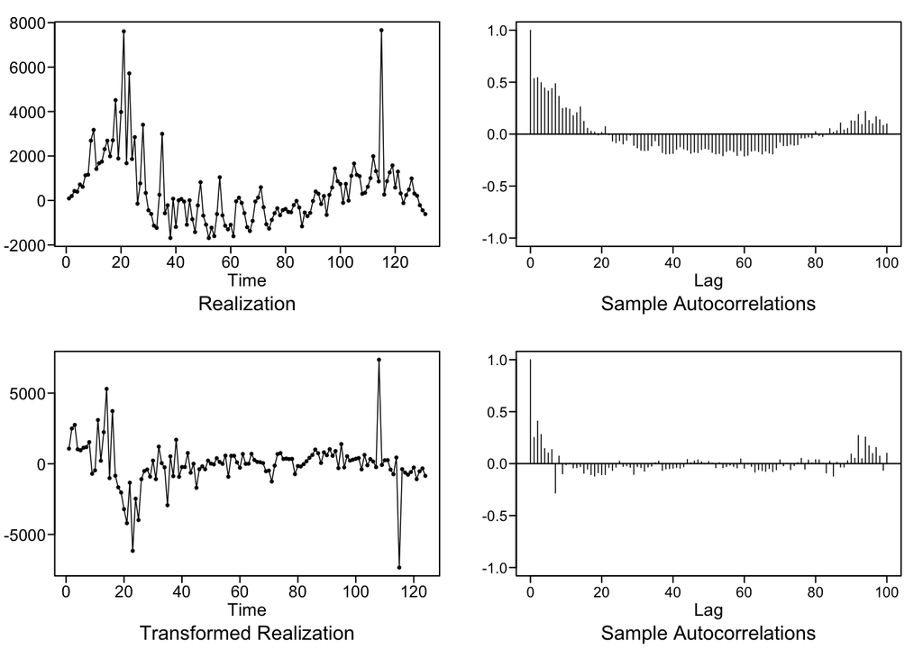

### Diagnose Model w/ aic.wge

```r
aic5.wge(us.diff.seas)
```

```
## ---------WORKING... PLEASE WAIT...
##
##
## Five Smallest Values of  aic
```

```
##       p    q        aic
## 17    5    1   14.57449
## 10    3    0   14.60386
## 13    4    0   14.61477
## 6     1    2   14.61527
## 8     2    1   14.61581
```

```r
aic5.wge(us.diff.seas,type = "bic")
```

```
## ---------WORKING... PLEASE WAIT...
##
##
## Five Smallest Values of  bic
```

```
##       p    q        bic
## 7     2    0   14.68775
## 10    3    0   14.69484
## 6     1    2   14.70625
## 8     2    1   14.70679
## 3     0    2   14.72173
```

### Diagnose white noise

Both of the Junge Box test show us that we reject the H null with pvalues that are < 0.05 alpha significance level.

```r
ljung.wge(us.diff.seas)$pval
```

```
## Obs 0.2522573 0.4096169 0.2803795 0.1452644 0.1021298 0.1354335 -0.2827722 0.07264095 -0.09804601 -0.01062144 0.004067316 -0.04130786 -0.03854601 -0.02866098 -0.09193388 -0.05167819 -0.1056372 -0.1193326 -0.08827532 -0.1061183 -0.1054081 -0.036613 -0.0654078 -0.03489691
```

```
## [1] 1.859792e-06
```

```r
ljung.wge(us.diff.seas, K=48)$pval
```

```
## Obs 0.2522573 0.4096169 0.2803795 0.1452644 0.1021298 0.1354335 -0.2827722 0.07264095 -0.09804601 -0.01062144 0.004067316 -0.04130786 -0.03854601 -0.02866098 -0.09193388 -0.05167819 -0.1056372 -0.1193326 -0.08827532 -0.1061183 -0.1054081 -0.036613 -0.0654078 -0.03489691 0.02370281 -0.02743256 -0.…
```

```
## [1] 0.003990771
```

### Estiamte Phis and Thetas

AIC Phi and Theta Estimates

```r
est.us.diff.seasAIC = est.arma.wge(us.diff.seas, p = 5, q=1)
```

```
##
## Coefficients of Original polynomial:
## -0.6097 0.4850 0.5047 0.0643 -0.2269
##
## Factor                 Roots                Abs Recip    System Freq
## 1+0.9305B             -1.0747               0.9305       0.5000
## 1+0.9405B+0.5775B^2   -0.8143+-1.0337i      0.7599       0.3562
## 1-1.2613B+0.4223B^2    1.4934+-0.3713i      0.6498       0.0388
##
##
```

```r
mean(us$hospitalizedCurrently)
```

```
## [1] 39625.17
```

BIC Phi Estiamtes

```r
est.us.diff.seasBIC = est.arma.wge(us.diff.seas, p = 2)
```

```
##
## Coefficients of Original polynomial:
## 0.1594 0.3740
##
## Factor                 Roots                Abs Recip    System Freq
## 1-0.6964B              1.4359               0.6964       0.0000
## 1+0.5370B             -1.8622               0.5370       0.5000
##
##
```

```r
mean(us$hospitalizedCurrently)
```

```
## [1] 39625.17
```

### Univariate Forecasts

#### ARIMA(5,1,1), s=7

##### Short Term

```r
shortARMA <- fore.aruma.wge(us$hospitalizedCurrently, phi = est.us.diff.seasAIC$phi, theta = est.us.diff.seasAIC$theta, d= 1, s = 7, n.ahead = 7, lastn = F, limits = T)
```

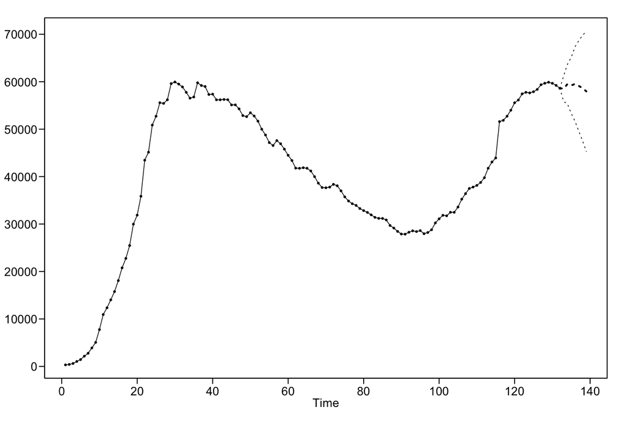

- AIC

```r
est.us.diff.seasAIC$aic
```

```
## [1] 14.57449
```

- Windowed ASE

```r
phis = est.us.diff.seasAIC$phi
thetas = est.us.diff.seasAIC$theta

trainingSize = 24
horizon = 7
ASEHolder = numeric()

for( i in 1:(124-(trainingSize + horizon) + 1))
{
  forecasts = fore.aruma.wge(us$hospitalizedCurrently[i:(i+(trainingSize-1))],phi = phis, theta = thetas, s = 7, d = 1, n.ahead = horizon)

  ASE = mean((us$hospitalizedCurrently[(trainingSize+i):(trainingSize+ i + (horizon) - 1)] - shortARMA$f)^2)

  ASEHolder[i] = ASE
}
```

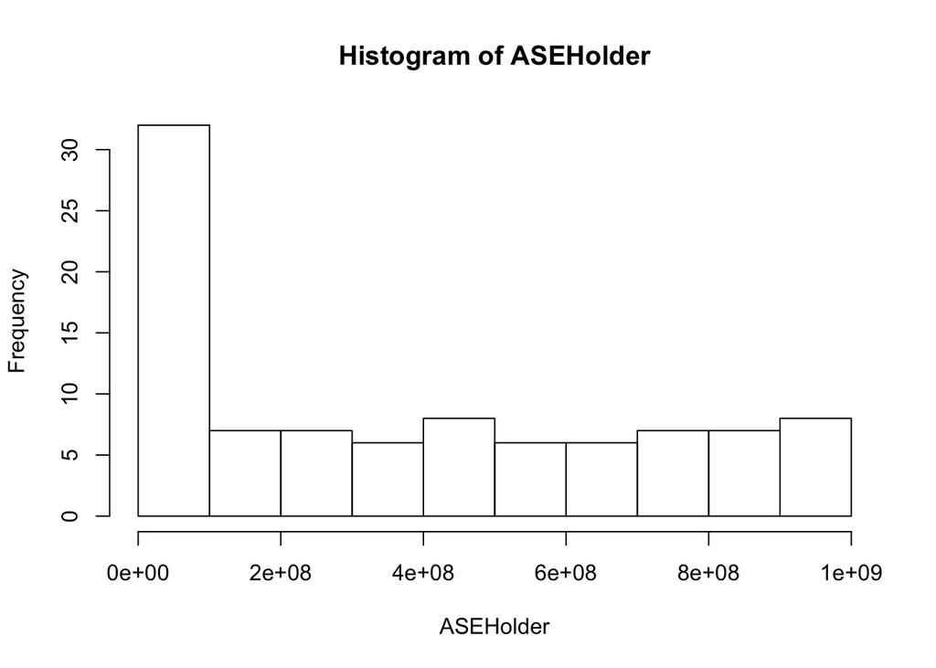

```r
invisible(ASEHolder)
hist(ASEHolder)
```

```r
WindowedASE = mean(ASEHolder)

summary(ASEHolder)
```

```
##      Min.   1st Qu.    Median      Mean   3rd Qu.      Max.
##   1272430  29588508 333408849 374722941 673776716 942860862
```

```r
WindowedASE
```

```
## [1] 374722941
```

```r
fs = fore.aruma.wge(us$hospitalizedCurrently[i:(i+(trainingSize+horizon)-1)],phi = phis, theta = thetas, s = 7, d = 1,n.ahead = 7, lastn = TRUE)
```

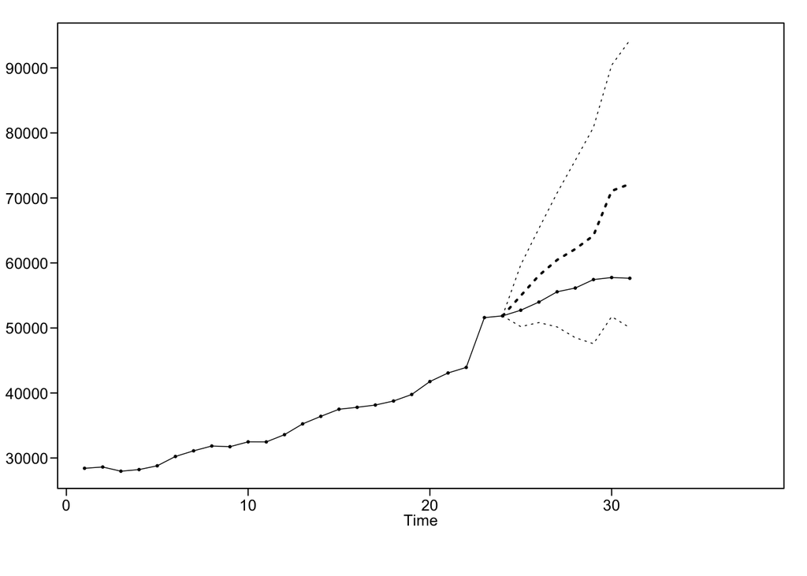

```r
ASE = mean((us$hospitalizedCurrently[(i+trainingSize):(i+(trainingSize+horizon)-1)] - fs$f )^2)
ASE
```

```
## [1] 73605156
```

##### Long Term

```r
longARMA <- fore.aruma.wge(us$hospitalizedCurrently, phi = est.us.diff.seasAIC$phi, theta = est.us.diff.seasAIC$theta, d= 1, s = 7, n.ahead = 90, lastn = F, limits = F)
```

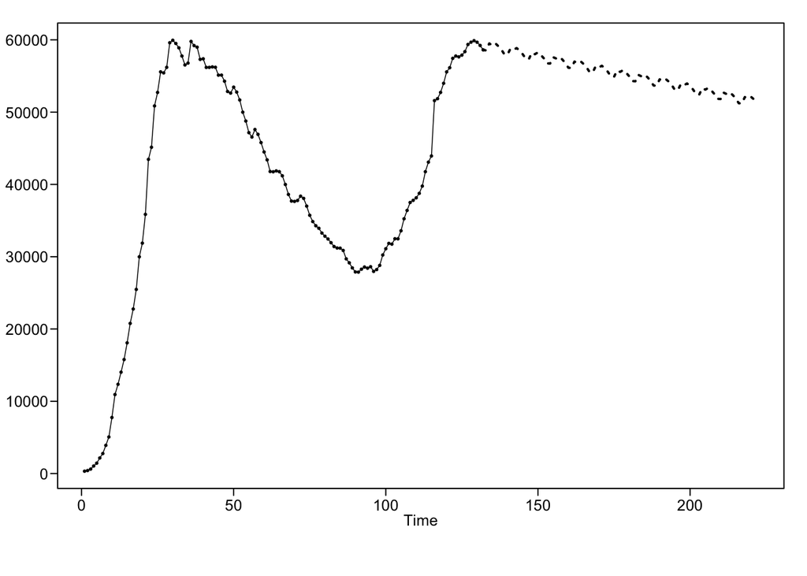

- Windowed ASE

```r
phis = est.us.diff.seasAIC$phi
thetas = est.us.diff.seasAIC$theta

trainingSize = 24
horizon = 90
ASEHolder = numeric()

for( i in 1:(124-(trainingSize + horizon) + 1))
{
  forecasts = fore.aruma.wge(us$hospitalizedCurrently[i:(i+(trainingSize-1))],phi = phis, theta = thetas, s = 7, d = 1,n.ahead = horizon)

  ASE = mean((us$hospitalizedCurrently[(trainingSize+i):(trainingSize+ i + (horizon) - 1)] - longARMA$f)^2)

  ASEHolder[i] = ASE
}
```

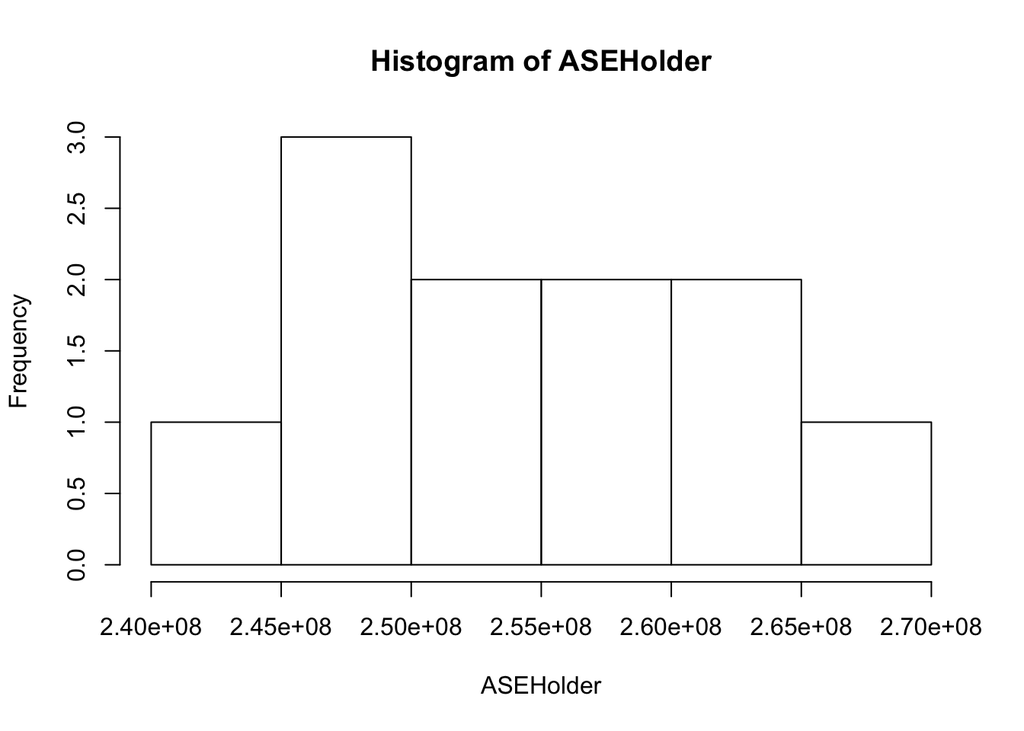

```r
invisible(ASEHolder)
hist(ASEHolder)
```

```r
WindowedASE = mean(ASEHolder)

summary(ASEHolder)
```

```
##      Min.   1st Qu.    Median      Mean   3rd Qu.      Max.
## 243601762 248462559 254633109 254917886 261033217 267272736
```

```r
WindowedASE
```

```
## [1] 254917886
```

```r
fs = fore.aruma.wge(us$hospitalizedCurrently[i:(i+(trainingSize+horizon)-1)],phi = phis, theta = thetas, s = 7, d = 1, n.ahead = 90, lastn = T)
```

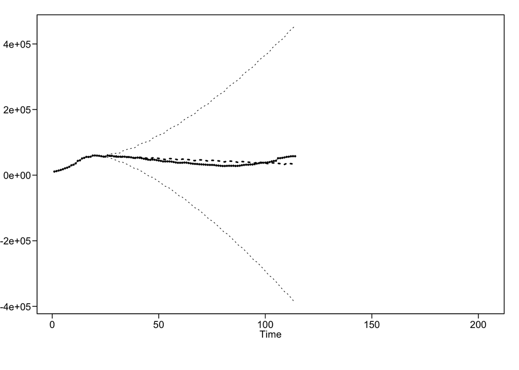

```r
ASE = mean((us$hospitalizedCurrently[(i+trainingSize):(i+(trainingSize+horizon)-1)] - fs$f )^2)
ASE
```

```
## [1] 108278159
```

#### ARIMA(2,1,0)

##### Short Term

```r
shortAR <- fore.aruma.wge(us$hospitalizedCurrently, phi = est.us.diff.seasBIC$phi, d=1, s=7, n.ahead = 7, lastn = FALSE, limits = FALSE)
```

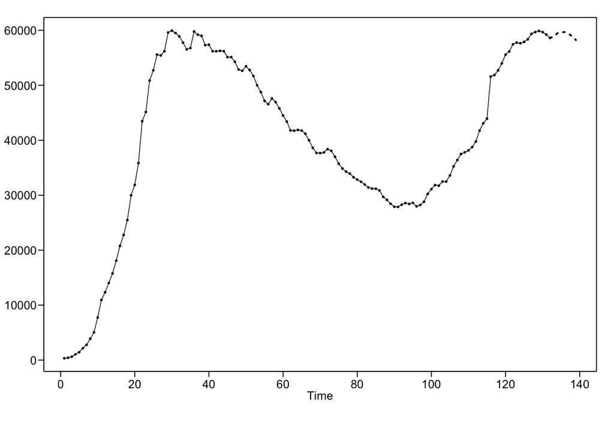

- AIC

```r
est.us.diff.seasBIC$aic
```

```
## [1] 14.61952
```

- Windowed ASE

```r
phis = est.us.diff.seasBIC$phi
thetas = est.us.diff.seasBIC$theta

trainingSize = 24
horizon = 7
ASEHolder = numeric()

for( i in 1:(124-(trainingSize + horizon) + 1))
{
  forecasts = fore.aruma.wge(us$hospitalizedCurrently[i:(i+(trainingSize-1))],phi = phis, theta = thetas, s = 7, d = 1, n.ahead = horizon)

  ASE = mean((us$hospitalizedCurrently[(trainingSize+i):(trainingSize+ i + (horizon) - 1)] - shortAR$f)^2)

  ASEHolder[i] = ASE
}
```

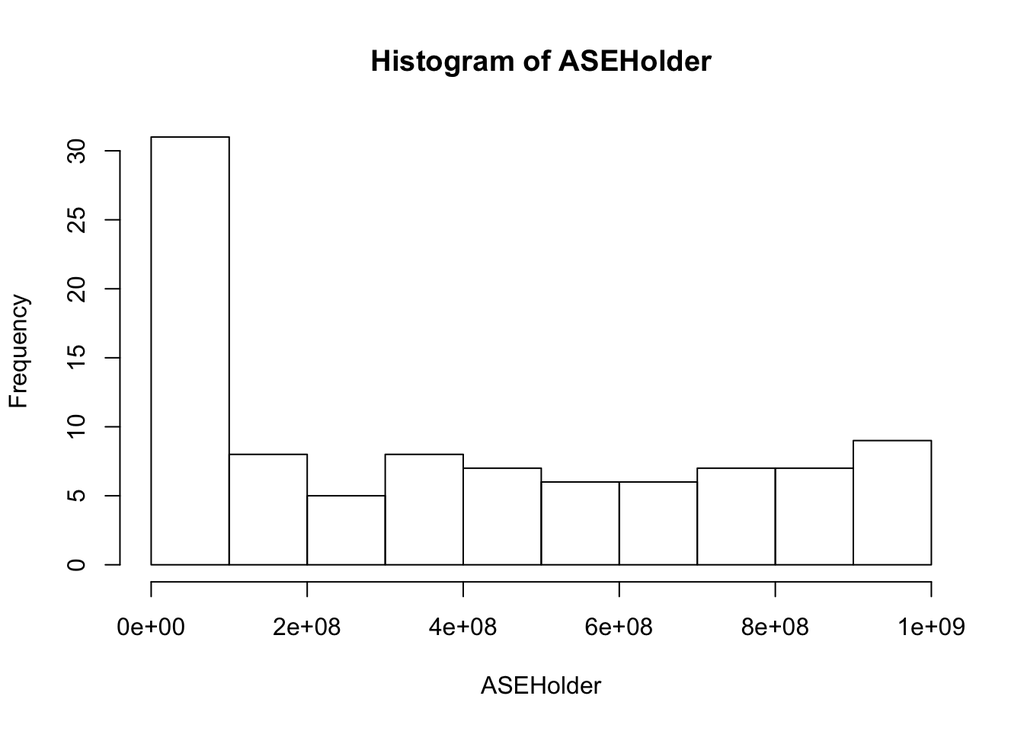

```r
invisible(ASEHolder)
hist(ASEHolder)
```

```r
WindowedASE = mean(ASEHolder)

summary(ASEHolder)
```

```
##      Min.   1st Qu.    Median      Mean   3rd Qu.      Max.
##   1637445  31817714 341701004 382068707 685537393 956760251
```

```r
WindowedASE
```

```
## [1] 382068707
```

```r
fs = fore.aruma.wge(us$hospitalizedCurrently[i:(i+(trainingSize+horizon)-1)],phi = phis, theta = thetas, s = 7, d = 1,n.ahead = 7, lastn = TRUE)
```

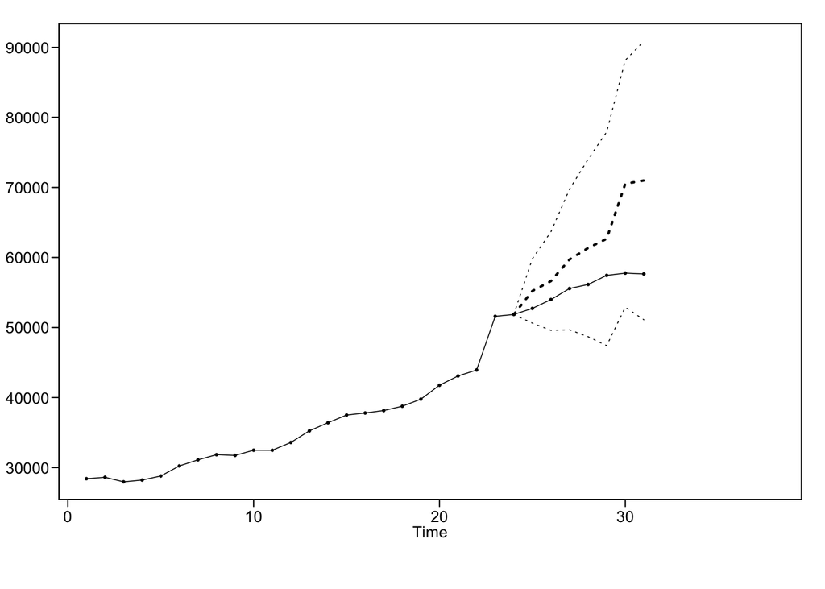

```r
ASE = mean((us$hospitalizedCurrently[(i+trainingSize):(i+(trainingSize+horizon)-1)] - fs$f )^2)
ASE
```

```
## [1] 60809514
```

##### Long Term

```r
longAR <- fore.aruma.wge(us$hospitalizedCurrently, phi = est.us.diff.seasBIC$phi, s= 7, d = 1, n.ahead = 90, lastn = FALSE, limits = FALSE)
```

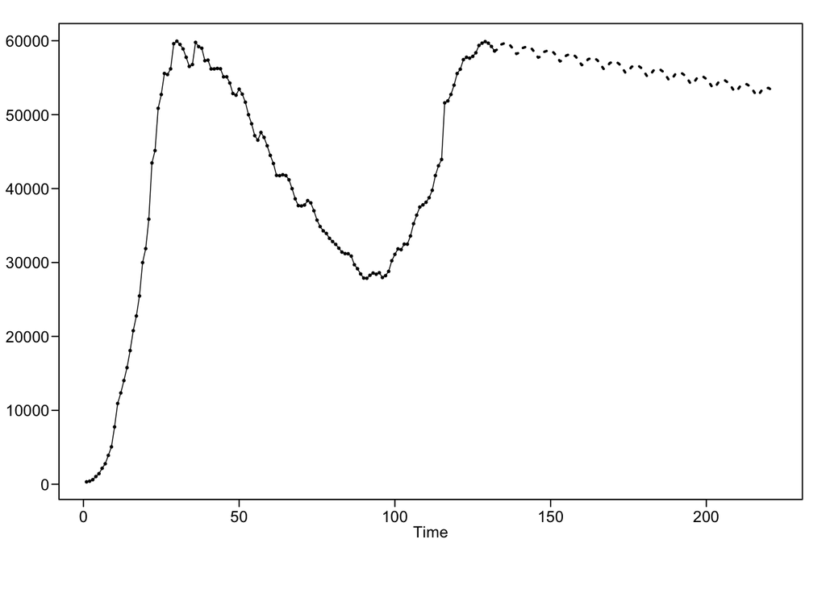

- ASE

```r
ASElongAR = mean((us$hospitalizedCurrently[(124-90+1):124]-longAR$f)^2)
ASElongAR
```

```
## [1] 293286598
```

- Windowed ASE

```r
phis = est.us.diff.seasBIC$phi
thetas = est.us.diff.seasBIC$theta

trainingSize = 24
horizon = 90
ASEHolder = numeric()

for( i in 1:(124-(trainingSize + horizon) + 1))
{
  forecasts = fore.aruma.wge(us$hospitalizedCurrently[i:(i+(trainingSize-1))],phi = phis, theta = thetas, s = 7, d = 1,n.ahead = horizon)

  ASE = mean((us$hospitalizedCurrently[(trainingSize+i):(trainingSize+ i + (horizon) - 1)] - longAR$f)^2)

  ASEHolder[i] = ASE
}
```

```r
ASEHolder
```

```
##  [1] 273011817 275072396 276591563 278271604 280408457 282811057 285096031
##  [8] 287205763 289262672 291232189 293286598
```

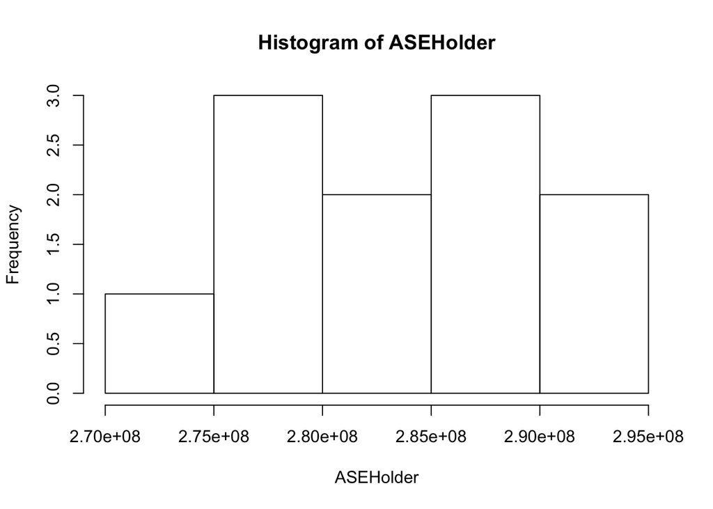

```r
hist(ASEHolder)
```

```r
WindowedASE = mean(ASEHolder)
```

```r
summary(ASEHolder)
```

```
##      Min.   1st Qu.    Median      Mean   3rd Qu.      Max.
## 273011817 277431584 282811057 282931831 288234217 293286598
```

```r
WindowedASE
```

```
## [1] 282931831
```

```r
fs = fore.aruma.wge(us$hospitalizedCurrently[i:(i+(trainingSize+horizon)-1)],phi = phis, theta = thetas, s = 7, d = 1,n.ahead = 90, lastn = TRUE)
```

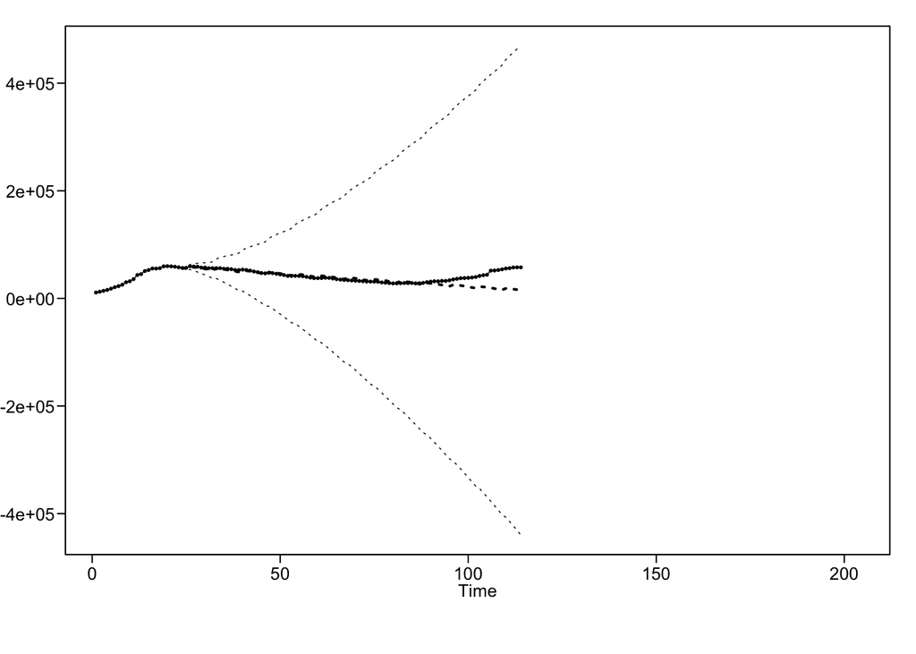

```r
ASE = mean((us$hospitalizedCurrently[(i+trainingSize):(i+(trainingSize+horizon)-1)] - fs$f )^2)
ASE
```

```
## [1] 185865366
```

#### MLR w/ Correlated Errors

```r
us.lm.fit = lm(hospitalizedCurrently~date, data = us)
us.lm.fit
```

```
##
## Call:
## lm(formula = hospitalizedCurrently ~ date, data = us)
##
## Coefficients:
## (Intercept)         date
##  -2690400.5        148.3
```

```
b. Diagnose a model using aic.wge: ARMA(2,1)
```

```r
us.fit.phi = aic.wge(us.lm.fit$residuals)
us.fit.phi
```

```
## $type
## [1] "aic"
##
## $value
## [1] 14.13534
##
## $p
## [1] 2
##
## $q
## [1] 1
##
## $phi
## [1]  1.9761677 -0.9827085
##
## $theta
## [1] 0.8124226
##
## $vara
## [1] 1295928
```

```
c. Fit an aruma model
```

```r
#without d and s
us.fit.1 = arima(us$hospitalizedCurrently, order = c(us.fit.phi$p,0,us.fit.phi$q))
us.fit.1
```

```
##
## Call:
## arima(x = us$hospitalizedCurrently, order = c(us.fit.phi$p, 0, us.fit.phi$q))
##
## Coefficients:
##          ar1      ar2      ma1  intercept
##       1.9833  -0.9899  -0.8148  39320.409
## s.e.  0.0110   0.0111   0.0622   2929.753
##
## sigma^2 estimated as 1336104:  log likelihood = -1122.02,  aic = 2254.04
```

```r
AIC(us.fit.1)
```

```
## [1] 2254.035
```

```
d. Checking for white noise: failure to to reject the H_null tells us the remainer of the data cannot be determined as any different than white noise.
```

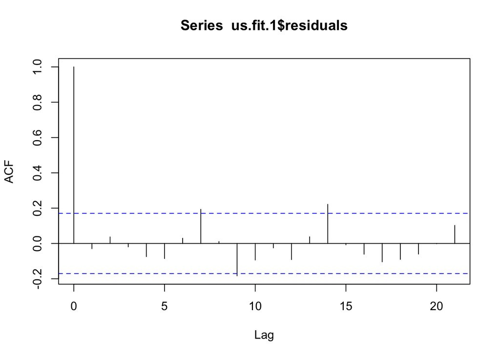

```r
acf(us.fit.1$residuals)
```

```r
ljung.wge(us.fit.1$residuals) # pval = .1493
```

```
## Obs -0.02987561 0.03687861 -0.01936297 -0.07479687 -0.08568575 0.02967657 0.1935121 0.010766 -0.1833414 -0.09389209 -0.02514747 -0.0914376 0.03776621 0.2217227 -0.007855923 -0.06113738 -0.1042505 -0.09046967 -0.06034636 -0.001906665 0.1023217 0.05696377 -0.104889 -0.05410579
```

```
## $test
## [1] "Ljung-Box test"
##
## $K
## [1] 24
##
## $chi.square
## [1] 31.15601
##
## $df
## [1] 24
##
## $pval
## [1] 0.1493352
```

5. Predictions

```r
us.preds7 = predict(us.fit.1, n.ahead = 7)
us.preds7$pred
```

```
## Time Series:
## Start = 133
## End = 139
## Frequency = 1
## [1] 58065.23 57398.09 56618.20 55731.85 54745.97 53668.08 52506.26
```

```r
us.preds90 = predict(us.fit.1, n.ahead = 90)
us.preds90$pred
```

```
## Time Series:
## Start = 133
## End = 222
## Frequency = 1
##  [1] 58065.23 57398.09 56618.20 55731.85 54745.97 53668.08 52506.26
##  [8] 51269.01 49965.29 48604.38 47195.86 45749.52 44275.30 42783.23
## [15] 41283.36 39785.68 38300.07 36836.22 35403.59 34011.34 32668.26
## [22] 31382.74 30162.68 29015.50 27948.03 26966.54 26076.63 25283.27
## [29] 24590.72 24002.55 23521.58 23149.91 22888.89 22739.13 22700.49
## [36] 22772.12 22952.41 23239.07 23629.15 24119.00 24704.39 25380.49
## [43] 26141.89 26982.71 27896.59 28876.75 29916.04 31006.98 32141.85
## [50] 33312.70 34511.42 35729.82 36959.63 38192.61 39420.58 40635.48
## [57] 41829.39 42994.65 44123.84 45209.87 46245.97 47225.83 48143.51
## [64] 48993.59 49771.14 50471.74 51091.53 51627.25 52076.20 52436.29
## [71] 52706.04 52884.57 52971.63 52967.57 52873.34 52690.47 52421.07
## [78] 52067.78 51633.81 51122.82 50538.99 49886.89 49171.54 48398.30
## [85] 47572.87 46701.23 45789.61 44844.45 43872.33 42879.94
```

6. Visualiztion of predictions

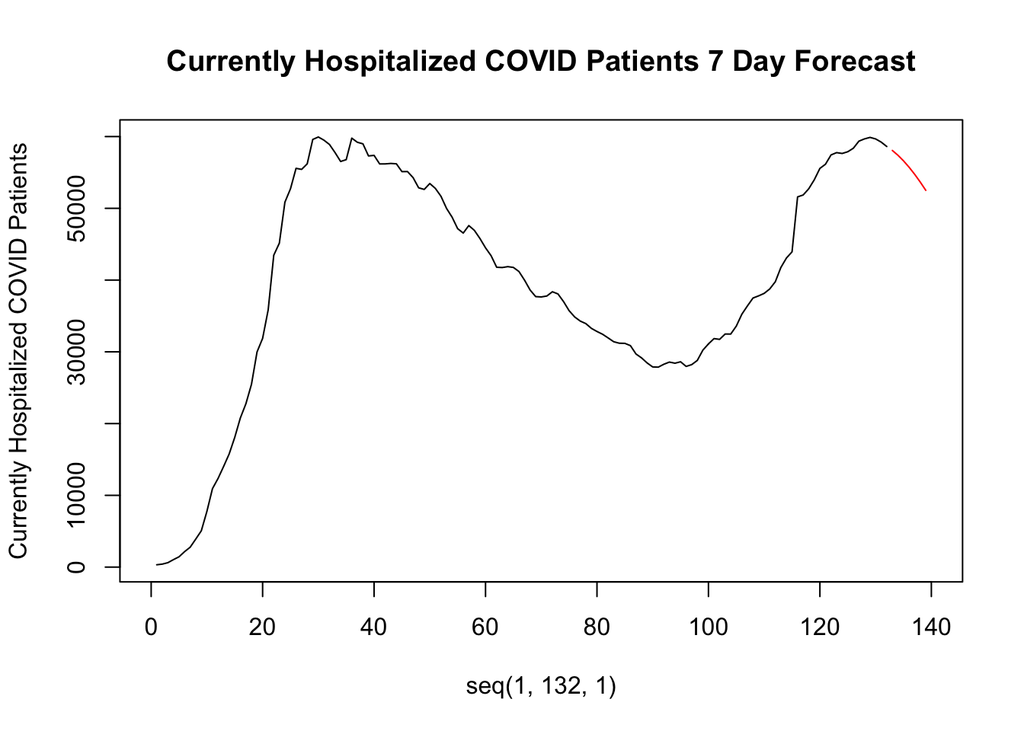

```r
#7 Day Forecast
plot(seq(1,132,1), us$hospitalizedCurrently, type = "l", xlim = c(0,140), ylab = "Currently Hospitalized COVID Patients", main = "Currently Hospitalized COVID Patients 7 Day Forecast")
lines(seq(133, 139, 1), us.preds7$pred, type= "l", col = "red")
```

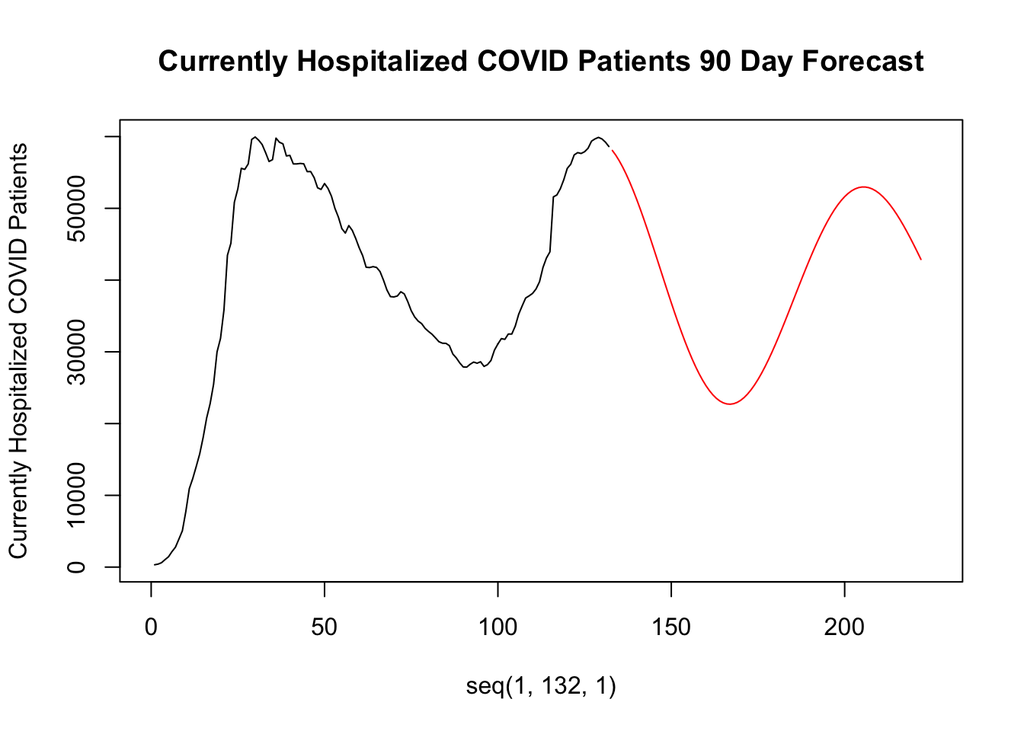

```r
#90 Day Forecast
plot(seq(1,132,1), us$hospitalizedCurrently, type = "l", xlim = c(0,225), ylab = "Currently Hospitalized COVID Patients", main = "Currently Hospitalized COVID Patients 90 Day Forecast")
lines(seq(133, 222, 1), us.preds90$pred, type= "l", col = "red")
```

```r
# Model cmort based on predicted part and temp using MLR with Cor Erros
#assuming data is loaded in dataframe CM
#ksfit = lm(cmort~temp+part+Week, data = CM)
#phi = aic.wge(ksfit$residuals) #AR(2)

#fit = arima(CM$cmort,order = c(phi$p,0,phi$q), seasonal = list(order = c(1,0,0), period = 52), xreg = cbind(CM$temp, CM$part, CM$Week))

#AIC(fit) #3166

# Check for whiteness of residuals
#acf(fit$residuals)
#ljung.wge(fit$residuals) # pval = .059
#ljung.wge(fit$residuals, K = 48) # pval = .004

#load the forecasted Part and Temp in a data frame
#next20 = data.frame(temp = predsTemp$f, part = predsPart$f, Week = seq(509,528,1))
#get predictions
#predsCMort = predict(fit,newxreg = next20)
#plot next 20 cmort wrt time
#plot(seq(1,508,1), CM$cmort, type = "l",xlim = c(0,528), ylab = "Cardiac Mortality", main = "20 Week Cardiac Mortality Forecast")
#lines(seq(509,528,1), predsCMort$pred, type = "l", col = "red")




#Find ASE  Need to forecast last 30 of known series.
#CMsmall = CM[1:478,]
#ksfit = lm(cmort~temp+part+Week, data = CMsmall)
#phi = aic.wge(ksfit$residuals)
#fit = arima(CMsmall$cmort,order = c(phi$p,0,0), seasonal = list(order = c(1,0,0), period = 52), xreg = cbind(CMsmall$temp, CMsmall$part, #CMsmall$Week))

#AIC(fit) #2990.101

#last30 = data.frame(temp = CM$temp[479:508], part = CM$part[479:508], CMWeek = seq(479,508,1))
#get predictions
#predsCMort = predict(fit,newxreg = last30)

#ASE = mean((CM$cmort[479:508] - predsCMort$pred)^2)
#ASE #84.2398

#plot(seq(1,508,1), CM$cmort, type = "l",xlim = c(0,528), ylab = "Cardiac Mortality", main = "Last 30 Week Cardiac Mortality Forecast")
#lines(seq(479,508,1), predsCMort$pred, type = "l", col = "red")
```

#### RNN

- Creating train / test data set

```r
library(nnfor)
head(us)
```

```
##           date positive negative pending hospitalizedCurrently
## 132 2020-03-17    11928    63104    1687                   325
## 131 2020-03-18    15099    84997    2526                   416
## 130 2020-03-19    19770   108407    3016                   617
## 129 2020-03-20    26025   138814    3330                  1042
## 128 2020-03-21    32910   177262    3468                  1436
## 127 2020-03-22    42169   213476    2842                  2155
##     hospitalizedCumulative inIcuCurrently inIcuCumulative
## 132                     55              0               0
## 131                     67              0               0
## 130                     85              0               0
## 129                    108              0               0
## 128                   2020              0               0
## 127                   3023              0               0
##     onVentilatorCurrently onVentilatorCumulative recovered death
```

[output cut: 20 more lines]

```r
usTrain.nn = ts(us$hospitalizedCurrently[1:122])
```

- Fitting NN model on train data set w/ default settings

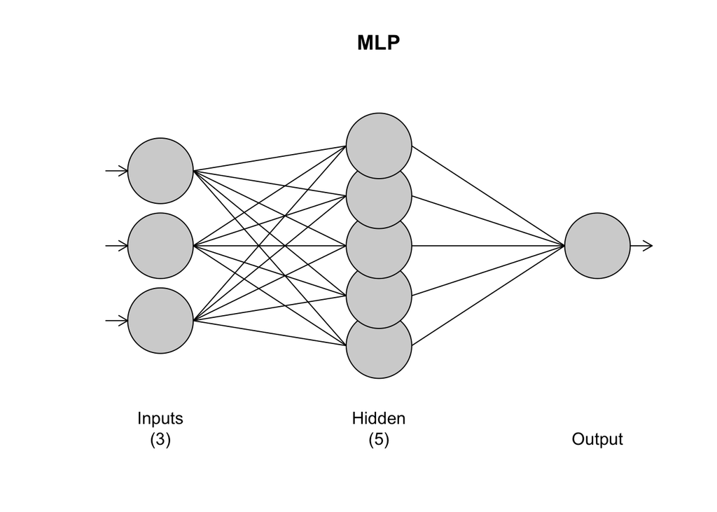

```r
us.nn.fit = mlp(usTrain.nn)
plot(us.nn.fit)
```

- Forecast horizon/step forward

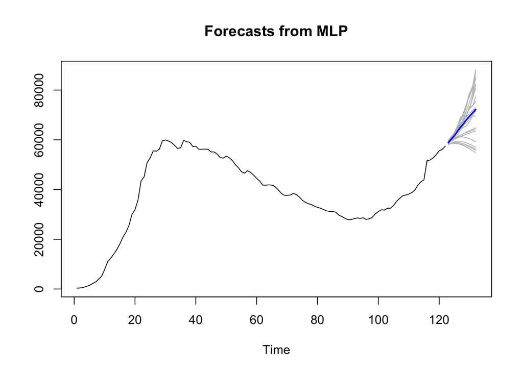

```r
us.nn.fit.fore = forecast(us.nn.fit, h=10)
plot(us.nn.fit.fore)
```

- Plot forecast against test set

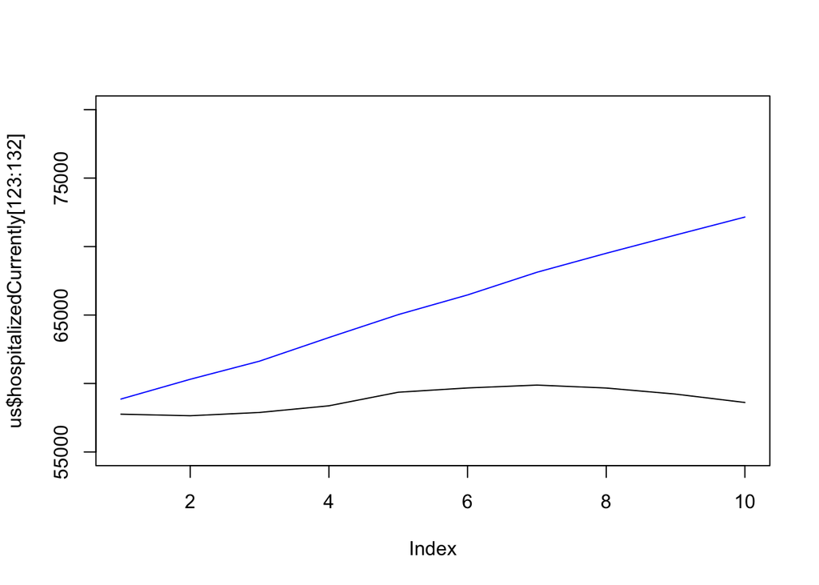

```r
plot(us$hospitalizedCurrently[123:132], type = "l", ylim = c(55000, 80000))
lines(seq(1:10), us.nn.fit.fore$mean, col = "blue")
```

- Calculate ASE

```r
ASEus.nn.fit.fore = mean((us$hospitalizedCurrently[123:132]-us.nn.fit.fore$mean)^2)
ASEus.nn.fit.fore
```

```
## [1] 60841313
```

```r
#phis = est.us.diff.seasBIC$phi
#thetas = est.us.diff.seasBIC$theta

#trainingSize = 24
#horizon = 90
#ASEHolder = numeric()

#for( i in 1:(124-(trainingSize + horizon) + 1))
#{
#  forecasts = fore.aruma.wge(us$hospitalizedCurrently[i:(i+(trainingSize-1))],phi = phis, theta = thetas, s = 7, d = 1,n.ahead = horizon)

#  ASE = mean((us$hospitalizedCurrently[(trainingSize+i):(trainingSize+ i + (horizon) - 1)] - longAR$f)^2)

#  ASEHolder[i] = ASE
#}
```

```r
#ASEHolder
#hist(ASEHolder)
#WindowedASE = mean(ASEHolder)
```

```r
#summary(ASEHolder)
#WindowedASE
```

```r
#fs = fore.aruma.wge(us$hospitalizedCurrently[i:(i+(trainingSize+horizon)-1)],phi = phis, theta = thetas, s = 7, d = 1,n.ahead = 90, lastn = TRUE)
#ASE = mean((us$hospitalizedCurrently[(i+trainingSize):(i+(trainingSize+horizon)-1)] - fs$f )^2)
#ASE
```